# Práctica 5 - Módulo 3

Implementación de LASSO

Diplomatura en Ciencias Sociales Computacionales y Humanidades Digitales (IDAES-UNSAM)

> Material elaborado originalmente por Carolina Pradier, Guido Weksler y Valentín Álvarez.

```r
library(tidyverse)
library(tidymodels)
library(gt)
library(kableExtra)
library(glmnet)
library(patchwork) # Visualizar múltiples plots juntos


options(dplyr.summarise.inform = FALSE, scipen = 999)
shape_values = c(4,1)
theme_set(theme_bw())
```

# 1 Introducción

Este material está destinado a ver la implementación del método de regularización LASSO y analizar su performance de manera comparada a la regresión logística. A lo largo del material, repasaremos el enfoque de **train-test** y el trade off existente entre sesgo-varianza a la hora de definir los parámetros de los modelos.

## 1.1 Retomando el ejemplo previo

A los fines de visualizar cómo opera el modelo, tomamos la base de juguete y vamos a continuar con el ejemplo de intentar clasificar a quienes realizan trabajo doméstico a partir de 2 predictores:

- horas_trabajo_mercado
- ingreso_familiar

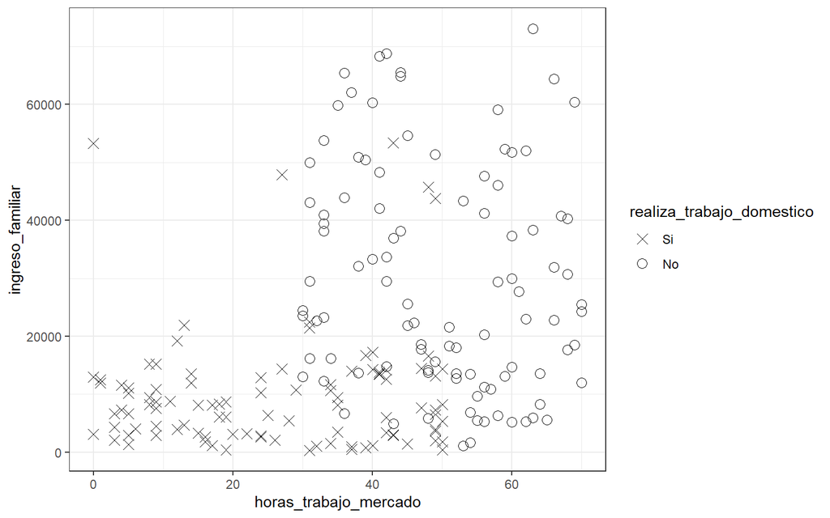

```r
base_juguete <- readRDS(file = "fuentes/eut_juguete_clase4.RDS") %>%
  #Ruta puede variar si se usa project de módulo "clase5/fuentes/eut_juguete_clase4.RDS"
  mutate(realiza_trabajo_domestico = factor(realiza_trabajo_domestico,
                                            levels = c("Si", "No")),
         horas_trabajo_mercado = as.numeric(horas_trabajo_mercado))

base_juguete %>%
  ggplot(
    aes(x = horas_trabajo_mercado,
        y = ingreso_familiar,
        shape = realiza_trabajo_domestico)
  ) +
  geom_point(size = 3)+
  scale_shape_manual(values=shape_values)
```

# 2 LASSO

## 2.1 En base completa

Aunque ya sabemos que no conviene modelar con la base completa, veamos que ocurre al hacerlo de esta manera, para luego pasar a hacer el train-test split.

Siguiendo con el lenguaje de tidymodels, para utilizar LASSO para un modelo de clasificación podemos aplicar `logistic_reg()`, cuyo parametro central es la penalidad que imponemos sobre los coeficientes. El parámetro `mixture = 1` es el que define que sea una regularización LASSO (cero sería *ridge*). El engine correspondiente es “glmnet”.

```r
lasso_model <- logistic_reg(
    penalty = 0.1,
    mixture = 1
  ) %>%
  set_engine("glmnet") %>%
  set_mode("classification")
```

Armamos un workflow y estimamos. En nuestra receta vamos a incluir un paso para estandarizar las variables, que es importante por estar sumando coeficientes de variables distintas.

```r
lasso_rec <- recipe(data = base_juguete,
                    formula = realiza_trabajo_domestico  ~ horas_trabajo_mercado +
                                         ingreso_familiar) %>%
  step_normalize(all_predictors())

lasso_wflow <- workflow() %>%
  add_model(lasso_model) %>%
  add_recipe(lasso_rec)

lasso_fit <- lasso_wflow %>%
  fit(data = base_juguete)
```

Veamos que ocurre con las predicciones (tomo 50 casos al azar)

```r
base_pred <- lasso_fit %>%
  augment(base_juguete)

set.seed(42)
base_pred %>%
  select(realiza_trabajo_domestico,.pred_class,.pred_No,.pred_Si) %>%
  sample_n(50)
```

```
## # A tibble: 50 × 4
##    realiza_trabajo_domestico .pred_class .pred_No .pred_Si
##    <fct>                     <fct>          <dbl>    <dbl>
##  1 No                        No             0.886    0.114
##  2 No                        No             0.803    0.197
##  3 Si                        Si             0.326    0.674
##  4 No                        No             0.704    0.296
##  5 Si                        Si             0.135    0.865
##  6 Si                        Si             0.112    0.888
##  7 Si                        Si             0.159    0.841
##  8 Si                        No             0.554    0.446
##  9 No                        No             0.619    0.381
## 10 No                        No             0.590    0.410
## # ℹ 40 more rows
```

Veamos ahora gráficamente todos los casos. Las predicciones correctas son aquellas en que las cruces están en rojo (realiza TDNR y predigo que lo realiza) y las que los circulos están en azul (no realiza TDNR y predigo que no lo hace).

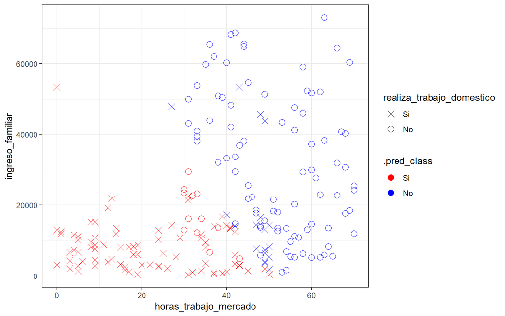

```r
ggplot(
    base_pred,
    aes(
      x = horas_trabajo_mercado,
      y = ingreso_familiar,
      shape = realiza_trabajo_domestico,
      color = .pred_class
    )
  ) +
  geom_point(size = 3) +
  scale_shape_manual(values=shape_values)+
  scale_color_manual(values=c("red","blue"))
```

- **¿Pueden imaginarse una frontera de decisión viendo el gráfico?**
- **¿Piensan que la regresión logística funciona mejor (respecto a otros modelos) cuando los grupos están bien separados o cuando hay mayor superposición?**

**¿Que pasa a medida que aumentamos lambda?**

En la práctica no vamos a necesitar este paso, pero para respondernos esta pregunta podemos usar un loop para estimar el modelo para varios valores de lambda.

Veamos qué pasó con los coeficientes.

```r
coefs
```

```
## [[1]]
## # A tibble: 3 × 3
##   term                  estimate penalty
##   <chr>                    <dbl>   <dbl>
## 1 (Intercept)            -0.0744       0
## 2 horas_trabajo_mercado   2.40         0
## 3 ingreso_familiar        1.80         0
##
## [[2]]
## # A tibble: 3 × 3
##   term                  estimate penalty
##   <chr>                    <dbl>   <dbl>
## 1 (Intercept)            -0.0548    0.01
## 2 horas_trabajo_mercado   2.07      0.01
## 3 ingreso_familiar        1.54      0.01
##
## [[3]]
## # A tibble: 3 × 3
##   term                  estimate penalty
##   <chr>                    <dbl>   <dbl>
## 1 (Intercept)            -0.0111     0.1
## 2 horas_trabajo_mercado   0.924      0.1
## 3 ingreso_familiar        0.581      0.1
##
## [[4]]
## # A tibble: 3 × 3
##   term                  estimate penalty
##   <chr>                    <dbl>   <dbl>
## 1 (Intercept)           -0.00294     0.2
## 2 horas_trabajo_mercado  0.458       0.2
## 3 ingreso_familiar       0.162       0.2
##
## [[5]]
## # A tibble: 3 × 3
##   term                    estimate penalty
##   <chr>                      <dbl>   <dbl>
## 1 (Intercept)           -0.0000306     0.3
## 2 horas_trabajo_mercado  0.0825        0.3
## 3 ingreso_familiar       0             0.3
##
## [[6]]
## # A tibble: 3 × 3
##   term                   estimate penalty
##   <chr>                     <dbl>   <dbl>
## 1 (Intercept)           -2.78e-17       2
## 2 horas_trabajo_mercado  0              2
## 3 ingreso_familiar       0              2
```

Ahora armamos un dataframe cómo para graficar y mostramos los resultados para cada valor del hiperparámetro.

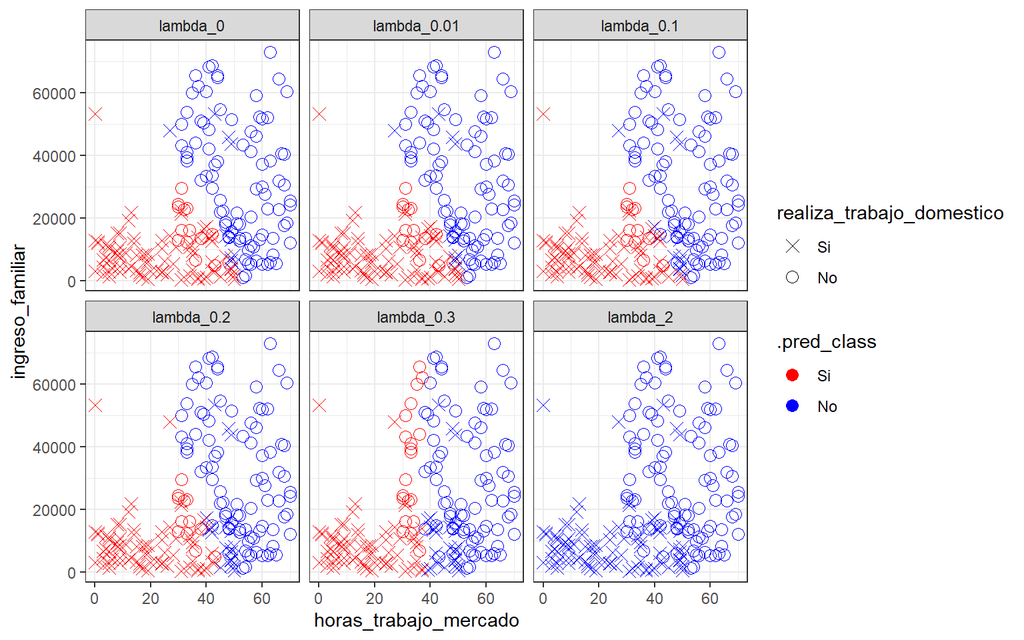

## 2.2 Aplicando train-test split

Hacemos el tran-test split y aprovechamos nuestro workflow para estimar el modelo con la base recortada.

```r
# Split
set.seed(132)

base_split <- initial_split(base_juguete)
base_train <- training(base_split)
base_test <- testing(base_split)

# Estimo con train
lasso_fit_train <-  lasso_wflow %>%
  fit(data = base_train)
```

Y ahora evaluamos la performance con datos nuevos.

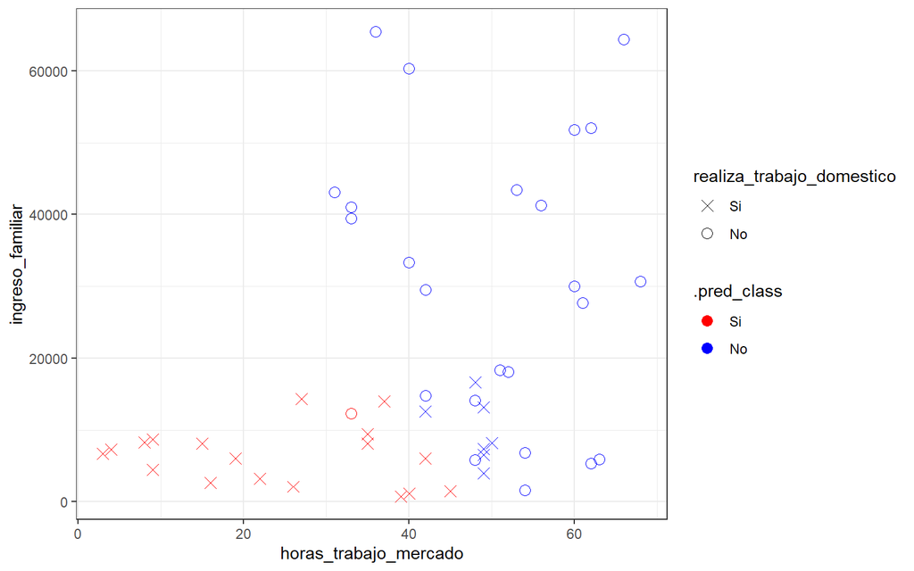

```r
# Aplico a test
lasso_fit_test <- lasso_fit_train %>%
  augment(base_test)

ggplot(
  lasso_fit_test,
  aes(
    x = horas_trabajo_mercado,
    y = ingreso_familiar,
    shape = realiza_trabajo_domestico,
    color = .pred_class
  )
) +
  geom_point(size = 3) +
  scale_shape_manual(values=shape_values)+
  scale_color_manual(values=c("red","blue"))
```

Repitamos para un lambda distinto. Primero armamos el nuevo modelo, luego reemplazamos el que teníamos en nuestro workflow.

```r
# Armo nuevo model
lasso_model2 <- logistic_reg(penalty = 0.3,
                             mixture = 1) %>%
  set_mode("classification") %>%
  set_engine("glmnet")

# Estimo con train
lasso_fit_train2 <-  lasso_wflow %>%
  remove_model() %>%
  add_model(lasso_model2) %>%
  fit(data = base_train)
```

Ahora lo aplicamos a la base de test.

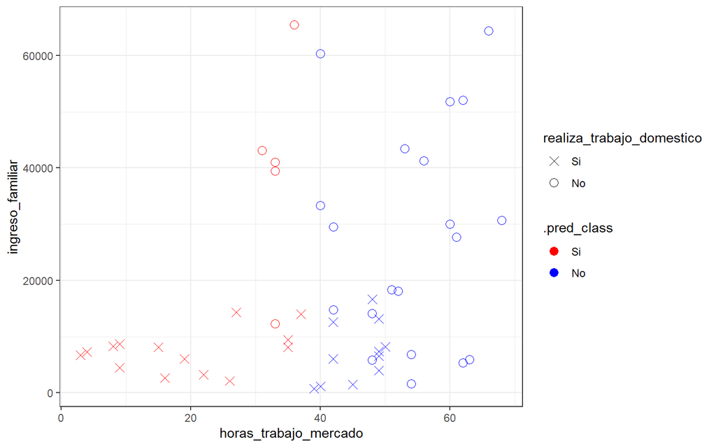

```r
# Aplico a test
lasso_fit_test2 <- lasso_fit_train2 %>%
  augment(base_test)

ggplot(
  lasso_fit_test2,
  aes(
    x = horas_trabajo_mercado,
    y = ingreso_familiar,
    shape = realiza_trabajo_domestico,
    color = .pred_class
  )
) +
  geom_point(size = 3) +
  scale_shape_manual(values=shape_values)+
  scale_color_manual(values=c("red","blue"))
```

## 2.3 Matriz de confusión y otras métricas

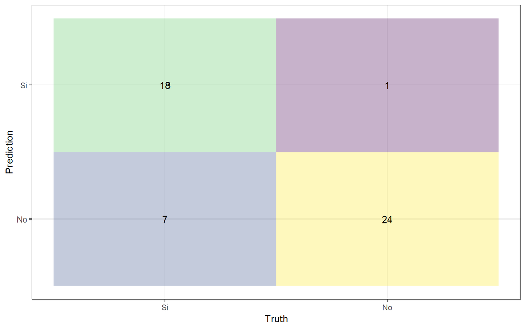

```r
cm <- conf_mat(data = lasso_fit_test,
               truth = realiza_trabajo_domestico,
               estimate = .pred_class )

suppressMessages(
  cm %>% autoplot("heatmap")+scale_fill_viridis_b(alpha = .3)
  )
```

```r
accuracy(data = lasso_fit_test,
         truth = realiza_trabajo_domestico,
         estimate = .pred_class)
```

```
## # A tibble: 1 × 3
##   .metric  .estimator .estimate
##   <chr>    <chr>          <dbl>
## 1 accuracy binary          0.84
```

# 3 Regresión logística

Agreguemos una regresión logística (como la de la clase pasada).

```r
log_model <-  logistic_reg() %>%
  set_mode("classification") %>%
  set_engine("glm")

log_fit <- log_model %>%
  fit(formula = realiza_trabajo_domestico  ~ horas_trabajo_mercado +
                                             ingreso_familiar,
      data = base_train)
```

# 4 Comparando modelos

Una de las potencialidades de **tidymodels** es que nos permite con mucha facilidad comparar métricas de cada uno de los modelos.

Se crea una lista de todos los modelos a evaluar, puedo luego con la función `imap_dfr` pasar cada uno de estos modelos como argumento de la función **augment()** y así agregar las predicciones de cada modelo al set de testing.

```r
#Lista de modelos
modelos <- list("logistica" = log_fit,
                "lasso1" = lasso_fit_train,
                "lasso2" = lasso_fit_train2)
```

La función `imap_dfr` permite aplicar la función augment a una lista de modelos, considerando la data de evaluación (base_test).

```r
base_test_preds <- imap_dfr(modelos,
                            augment,
                            new_data = base_test,
                            .id = "model")

#Visualizando las columnas generadas
base_test_preds %>%
  select(model,
         realiza_trabajo_domestico,
         .pred_class,
         .pred_No,
         .pred_Si) %>%
  sample_n(10)
```

```
## # A tibble: 10 × 5
##    model     realiza_trabajo_domestico .pred_class .pred_No .pred_Si
##    <chr>     <fct>                     <fct>          <dbl>    <dbl>
##  1 logistica No                        No             0.615 0.385
##  2 logistica No                        No             0.996 0.00371
##  3 lasso1    Si                        Si             0.396 0.604
##  4 logistica No                        No             0.999 0.000823
##  5 lasso1    Si                        Si             0.399 0.601
##  6 lasso1    No                        No             0.879 0.121
##  7 logistica No                        No             0.713 0.287
##  8 lasso2    Si                        Si             0.481 0.519
##  9 lasso1    No                        No             0.803 0.197
## 10 logistica No                        No             0.738 0.262
```

La función **metric_set()** nos permite establecer un conjunto de metricas de interés que luego podemos aplicar sobre nuestros modelos para compararlos.

```r
multi_metric <- metric_set(accuracy, sensitivity, specificity)
```

Para aplicarlas a cada modelo hay que agrupar por modelo.

```r
base_test_preds %>%
  group_by(model) %>%
  multi_metric(truth = realiza_trabajo_domestico,
               estimate = .pred_class) %>%
  arrange(.metric, .estimate)
```

```
## # A tibble: 9 × 4
##   model     .metric     .estimator .estimate
##   <chr>     <chr>       <chr>          <dbl>
## 1 lasso2    accuracy    binary          0.68
## 2 lasso1    accuracy    binary          0.84
## 3 logistica accuracy    binary          0.86
## 4 lasso2    sensitivity binary          0.56
## 5 lasso1    sensitivity binary          0.72
## 6 logistica sensitivity binary          0.76
## 7 lasso2    specificity binary          0.8
## 8 lasso1    specificity binary          0.96
## 9 logistica specificity binary          0.96
```

# 5 Visualmente

Luego de haber revisado las métricas, se encontraron diferencias en la performance de distintos modelos. En este punto, vamos a realizar una simulación de N observaciones para visualizar la frontera de decisión de cada uno de los modelos (decision boundary).

```r
source("plot_decision_boundary.R")
#Ruta puede variar source("clase5/plot_decision_boundary.R")
p_lasso <- plot_decision_boundary(
  data = base_juguete,
  model = lasso_fit,
  x_names = c("horas_trabajo_mercado", "ingreso_familiar"),
  y_name = "realiza_trabajo_domestico",
  n_points = 100,
  model_name = "Lasso (lambda=0.1)"
)
```

```
## [1] "Cantidad de datos simulados: 10000"
```

```r
p_log <- plot_decision_boundary(
  data = base_juguete,
  model = log_fit,
  x_names = c("horas_trabajo_mercado", "ingreso_familiar"),
  y_name = "realiza_trabajo_domestico",
  n_points = 100,
  model_name = "Regresión logística"
)
```

```
## [1] "Cantidad de datos simulados: 10000"
```

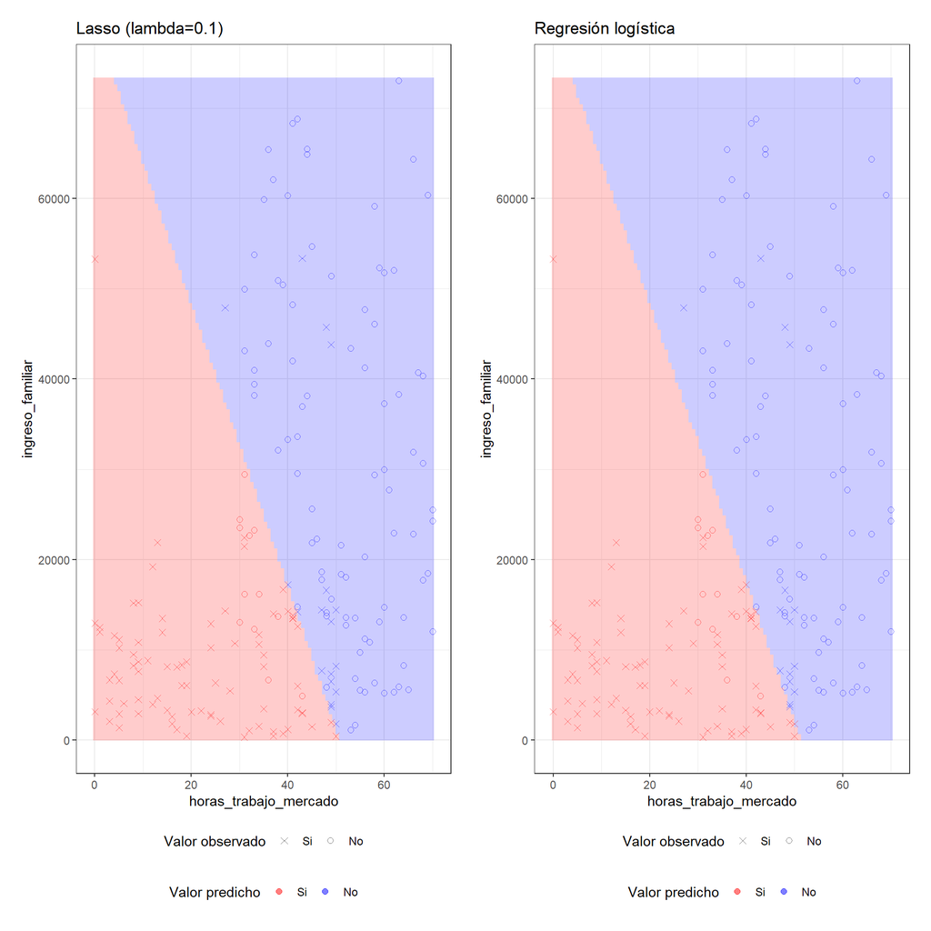

```r
wrap_elements(p_lasso) + wrap_elements(p_log)
```

Se observa que ambos modelos muestran una frontera de decisión lineal. Notar que, aunque son similares, no son iguales y por eso se observaban métricas diferentes en el punto anterior.

# 6 Resumen

- Con LASSO podemos elegir el mejor entre múltiples modelos de regresión.
- Aplica tanto para regresión lineal como para regresión logística.
- Es importante normalizar las variables en la receta.
- Si no elegimos bien el hiperparámetro ( *lambda* ) los resultados pueden ser decepcionantes. Para esto vamos a usar cross-validation.